# BCCIO Analysis

```r
library(ggpubr)
```

Read data from GSE123813 (pape: clonal replacement of tumor-specific T cells following PD-1 blockade) https://www.ncbi.nlm.nih.gov/geo/query/acc.cgi?acc=GSE123813

```r
## Read data
BCCIO.read <- read.table("C:\\Users\\Ryan\\Downloads\\GSE 123813\\bcc_scRNA_counts.txt", row.names = 1, sep="\t", as.is=T)
```

```r
memory.limit(size = 16000000)
```

```
[1] 1.6e+07
```

Pre-processing workflow

```r
BCCIO <- NormalizeData(BCCIO, normalization.method= "LogNormalize", scale.factor = 10000) # Normalize feature expression

BCCIO <- FindVariableFeatures(BCCIO, selection.method = "vst", nfeatures = 2000) # Feature selection (highly variable features)

all.genes <- rownames(BCCIO)
BCCIO <- ScaleData(BCCIO, features = all.genes) # Scale data in preparation for PCA
BCCIO <- RunPCA(BCCIO, features = VariableFeatures(object = BCCIO)) # Perform PCA
```

Checkpoint (Save Work Here)

```r
## To load data use load(filelocation) function
load("C:\\Ryan\\Documents\\Nie Research Project\\GSE 123813\\BCCIO")
```

```
cannot open compressed file 'C:\Ryan\Documents\Nie Research Project\GSE 123813\BCCIO', probable reason 'No such file or directory'Error in readChar(con, 5L, useBytes = TRUE) : cannot open the connection
```

Elbow Plot (Determine # of PCs to consider)

```r
ElbowPlot(BCCIO, ndims=50)
DimHeatmap(BCCIO, dims = 1:24, cells = 500, balanced = TRUE)
```

[output not shown]

Test out Clustering (Varying Resolution Levels) Higher resolution = greater clustering

```r
BCCIO <- FindClusters(BCCIO, resolution = 0.3, algorithm = 3)
```

```
Modularity Optimizer version 1.3.0 by Ludo Waltman and Nees Jan van Eck

Number of nodes: 53029
Number of edges: 2065874

Running smart local moving algorithm...
```

```
Maximum modularity in 10 random starts: 0.9516
Number of communities: 26
Elapsed time: 88 seconds
```

```r
BCCIO.markers <- FindAllMarkers(BCCIO, test.use = 'wilcox', min.pct = 0.25, logfc.threshold = 0.50, max.cells.per.ident = 200)
```

[output not shown]

[output cut: 35 more lines]

[output not shown]

Clustering comparison heatmap

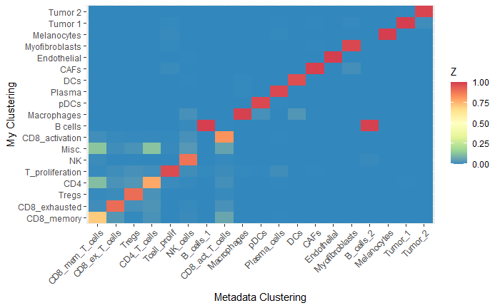

Comparison of Pre- and Post-Treatment

```r
BCCIO.pre <- subset(BCCIO, idents=c("pre"))
```

```
Error in WhichCells.Seurat(object = x, cells = cells, idents = idents,  :
  Cannot find the following identities in the object: pre
```

Gene investigation

Average gene expression

```r
bcc.response.averages <- AverageExpression(bcc.subset)
bcc.response.averages <- AverageExpression(bcc.subset)
bcc.response.averages.pd1 <- bcc.response.averages[["RNA"]][c("TCF7", "PDCD1", "CD274", "PDCD1LG2"),]
bcc.response.averages.pd1 <- bcc.response.averages[["RNA"]][c("TCF7", "PDCD1", "CD274", "PDCD1LG2"),]
View(bcc.respone.averages.pd1)
```

```
Error in View : object 'bcc.respone.averages.pd1' not found
```

Average gene expression divided by celltype

```r
bcc.tcells.pd1.averages.test <- melt(bcc.tcells.pd1.averages, id.vars = c("Patient.ID", "Patient"), measure.vars = c("PDCD1", "CD274", "PDCD1LG2", "TCF7"))
```

```
Error: id variables not found in data: Patient
```

Examine differences between pretreatment and posttreatment of responders and nonresponders

Create objects

```r
save(BCC.responder.pre, file="C:\\Users\\Ryan\\Documents\\Nie Research Project\\GSE 123813\\BCCresponderpre")
save(BCC.responder.post, file-"C:\\Users\\Ryan\\Documents\\Nie Research Project\\GSE 123813\\BCCresponderpost")
```

```
Error in save(BCC.responder.post, file - "C:\\Users\\Ryan\\Documents\\Nie Research Project\\GSE 123813\\BCCresponderpost") :
  object ‘file - "C:\\Users\\Ryan\\Documents\\Nie Research Project\\GSE 123813\\BCCresponderpost"’ not found
```

Comparison of BCC Responder vs. Nonresponder, Pretreatment vs. Posttreatment for all cells

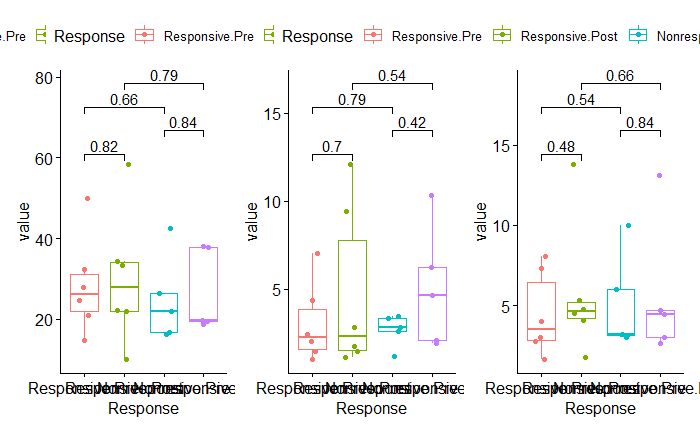

```r
## Celltypes that are interesting: CD8_activation, CD8_exhausted, CD8_memory, CD4, Tregs, T_proliferation, Macrophages, Tumor 1, Tumor 2, B cells, NK

CD8activated_graph <- fourway_diffexpression_MHCandHSP("CD8_activation", "Activated CD8+ T cells")
CD8exhausted_graph <- fourway_diffexpression_MHCandHSP("CD8_exhausted", "Exhausted CD8+ T cells")

CD8memory_graph <- fourway_diffexpression_MHCandHSP("CD8_memory", "Memory CD8+ T cells")
CD4_graph <- fourway_diffexpression_MHCandHSP("CD4", "CD4+ T cells")
Tregs_graph <- fourway_diffexpression_MHCandHSP("Tregs", "Regulatory T cells")
Tproliferation_graph <- fourway_diffexpression_MHCandHSP("T_proliferation", "Proliferating T cells")

Macrophage_graph <- fourway_diffexpression_MHCandHSP("Macrophages", "Macrophages")
Malignant_graph <- fourway_diffexpression_MHCandHSP(c("Tumor 1", "Tumor 2"), "Malignant cells")
Bcell_graph <- fourway_diffexpression_MHCandHSP("B cells", "B cells")
NK_graph <- fourway_diffexpression_MHCandHSP("NK", "NK cells")
```

Comparison of intra-patient trends between responders and nonresponders

Redo volcano plots for responders vs. nonresponders, pretreatment and posttreatment

```r
for (i in 1:length(celltypes)) {
  assign(paste0("BCC.pre.", celltypes[i]), bioc_volcano(dataset=BCC.pre,
                                                        celltype=celltypes[i],
                                                        group="response",
                                                        ident="Responsive", ident2="Nonresponsive",
                                                        pCutoff=0.05, FCcutoff=0.5, title=celltypesnames[i]))
}
```

[output not shown]

[output cut: 722 more lines]

[output not shown]

```r
BCC.pre.malignant <- bioc_volcano(dataset=BCC.pre, celltype=c("Tumor 1", "Tumor 2"), group="response", ident="Responsive", ident2="Nonresponsive", pCutoff=0.05, FCcutoff=0.5, title = "Malignant Cells")
```

[output not shown]

[output cut: 43 more lines]

[output not shown]

```r
for (i in 1:length(celltypes)) {
  assign(paste0("BCC.post.", celltypes[i]), bioc_volcano(dataset=BCC.post,
                                                        celltype=celltypes[i],
                                                        group="response",
                                                        ident="Responsive", ident2="Nonresponsive",
                                                        pCutoff=0.05, FCcutoff=0.5, title=celltypesnames[i]))
}
```

[output not shown]

[output cut: 753 more lines]

[output not shown]

```r
BCC.post.malignant <- bioc_volcano(dataset=BCC.post, celltype=c("Tumor 1", "Tumor 2"), group="response", ident="Responsive", ident2="Nonresponsive", pCutoff=0.05, FCcutoff=0.5, title = "Malignant Cells")
```

[output not shown]

[output cut: 36 more lines]

[output not shown]

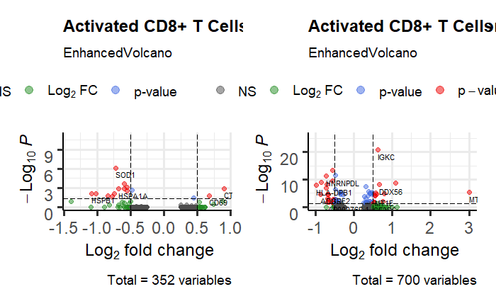

```r
BCC.pre.CD8_activation + BCC.post.CD8_activation
```

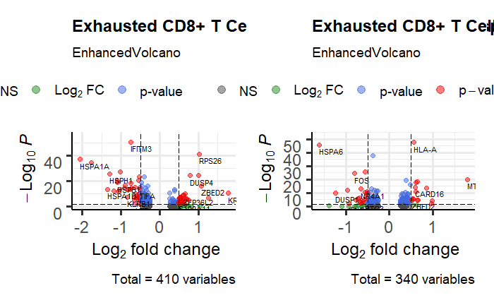

```r
BCC.pre.CD8_exhausted + BCC.post.CD8_exhausted
```

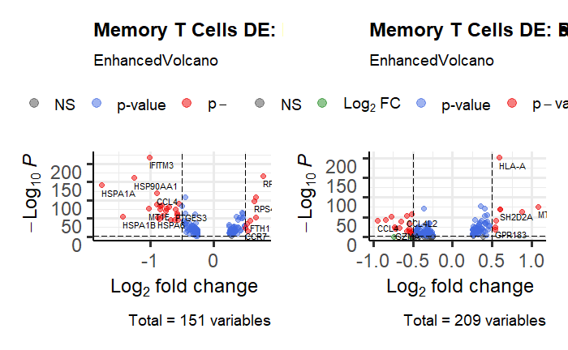

```r
BCC.pre.CD8_memory + BCC.post.CD8_memory
```

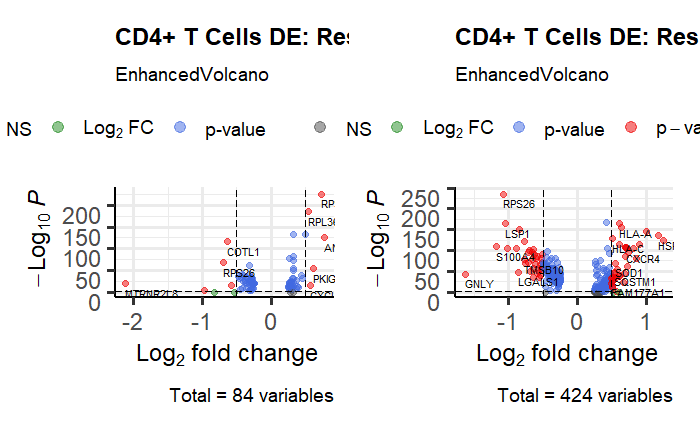

```r
BCC.pre.CD4 + BCC.post.CD4
```

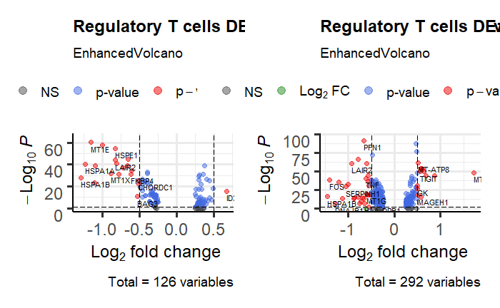

```r
BCC.pre.Tregs + BCC.post.Tregs
```

[figure not shown]

```r
BCC.pre.T_proliferation + BCC.post.T_proliferation
```

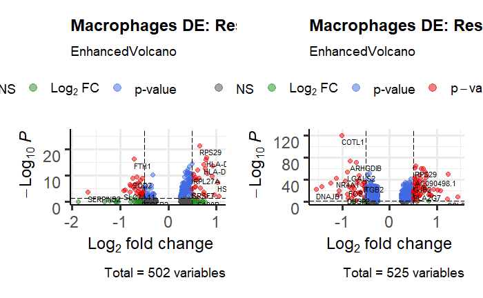

```r
BCC.pre.Macrophages + BCC.post.Macrophages
```

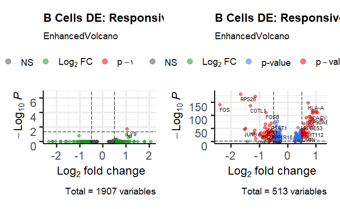

```r
`BCC.pre.B cells` + `BCC.post.B cells`
```

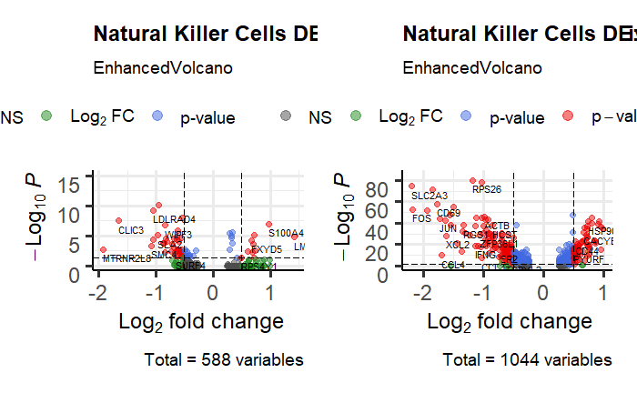

```r
BCC.pre.NK + BCC.post.NK
```

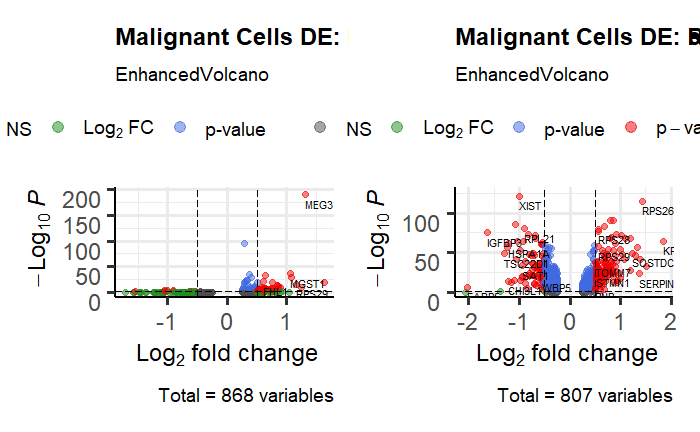

```r
BCC.pre.malignant + BCC.post.malignant
```

Create a dumbbell plot comparing the differential expression of genes between responders and nonresponders, pretreatment vs. posttreatment (Regulatory T cells)

```r
BCC.pre.Tregs.data <- BCC.pre.Tregs$data %>% select(GeneNames, xvals, yvals)
BCC.post.Tregs.data <- BCC.post.Tregs$data %>% select(GeneNames, xvals, yvals)

BCC.pre.Tregs.data <- filter(BCC.pre.Tregs.data, xvals < -0.5 | xvals > 0.5, yvals < 0.05)
BCC.post.Tregs.data <- filter(BCC.post.Tregs.data, xvals < -0.5 | xvals > 0.5, yvals < 0.05)

BCC.pre.Tregs.data$xvals[BCC.pre.Tregs.data$xvals < -2] <- -2
BCC.pre.Tregs.data$xvals[BCC.pre.Tregs.data$xvals > 2] <- 2

BCC.post.Tregs.data$xvals[BCC.post.Tregs.data$xvals < -2] <- -2
BCC.post.Tregs.data$xvals[BCC.post.Tregs.data$xvals > 2] <- 2

BCC.pre.Tregs.data$Treatment <- "Pre-treatment"
BCC.post.Tregs.data$Treatment <- "Post-treatment"

BCC.Tregs.data <- rbind(BCC.pre.Tregs.data, BCC.post.Tregs.data)
BCC.Tregs.data <- BCC.Tregs.data %>% group_by(GeneNames) %>% filter(n()>1)

BCC.Tregs.data <- BCC.Tregs.data[order(BCC.Tregs.data$GeneNames),]
BCC.Tregs.data$paired <- 0
for (i in 1:nrow(BCC.Tregs.data)) {
  BCC.Tregs.data$paired[i] <- ceiling(i/2)
}

BCC.Tregs.data$yvals <- -log10(BCC.Tregs.data$yvals)

BCC.Tregs.data %>%
  ggplot(aes(x = xvals, y = GeneNames)) +
  labs(title = "Regulatory T cells",
       x = expression("Log"[2]*" Fold Change"),
       y = "Gene") +
  geom_line(aes(group = paired), color="black", size=1) +
  geom_point(aes(color = Treatment, size = yvals)) +
  guides(size = FALSE) +
  theme_light() +
  theme(legend.position="top",
        plot.title = element_text(color="black", size=24, face="bold", hjust = 0.5)) +
  xlim(-2,2)
```

[output not shown]

Dumbbell charts for every cell type

```r
celltypes <- c("CD8_activation", "CD8_exhausted", "CD8_memory", "CD4", "Tregs", "T_proliferation", "Macrophages", "B cells", "NK")

celltypesnames <- c("Activated CD8+ T Cells", "Exhausted CD8+ T Cells", "Memory T Cells", "CD4+ T Cells", "Regulatory T cells", "Proliferating T Cells", "Macrophages", "B Cells", "Natural Killer Cells")

df_pre <- list(BCC.pre.CD8_activation, BCC.pre.CD8_exhausted, BCC.pre.CD8_memory, BCC.pre.CD4, BCC.pre.Tregs, BCC.pre.T_proliferation, BCC.pre.Macrophages, `BCC.pre.B cells`, BCC.pre.NK)

df_post <- list(BCC.post.CD8_activation, BCC.post.CD8_exhausted, BCC.post.CD8_memory, BCC.post.CD4, BCC.post.Tregs, BCC.post.T_proliferation, BCC.post.Macrophages, `BCC.post.B cells`, BCC.post.NK)

for (i in 1:length(celltypes)) {
  assign(paste0("dumbbell.", celltypes[i]), BCC_diffexp_dumbbell(df_pre[[i]], df_post[[i]], 0, 0.05, celltypesnames[i]))
}

dumbbell.malignant <- BCC_diffexp_dumbbell(BCC.pre.malignant, BCC.post.malignant, 0, 0.05, "Malignant Cells")

dumbbell.CD8_activation
dumbbell.CD8_exhausted
dumbbell.CD8_memory
dumbbell.CD4
dumbbell.Tregs
dumbbell.T_proliferation
dumbbell.Macrophages
`dumbbell.B cells`
dumbbell.NK
dumbbell.malignant
```

[output not shown]

Dumbbell chart analysis comparing differences in responders and nonresponders in their differential expression pretreatment vs. posttreatment

```r
## Create objects for each patient

Idents(BCCIO) <- BCCIO$patient
patients <- levels(Idents(BCCIO))

memory.limit(1600000000)
for (i in 1:length(patients)) {
  assign(paste0("BCC.", patients[i]), subset(BCCIO, idents=patients[i]))
}

BCC.patients <- list(BCC.su001, BCC.su002, BCC.su003, BCC.su004, BCC.su005, BCC.su006, BCC.su007, BCC.su008, BCC.su009, BCC.su010, BCC.su012)

BCC.patients.char <- c("BCC.su001", "BCC.su002", "BCC.su003", "BCC.su004", "BCC.su005", "BCC.su006", "BCC.su007", "BCC.su008", "BCC.su009", "BCC.su010", "BCC.su012")

for (i in 1:length(BCC.patients)) {
  Idents(BCC.patients[[i]]) <- BCC.patients[[i]]$seurat_clusters
  assign(paste0(BCC.patients.char[i], ".avg"), AverageExpression(BCC.patients[[i]], add.ident = "treatment"))
}

BCC.patients.avg <- list(BCC.su001.avg, BCC.su002.avg, BCC.su003.avg, BCC.su004.avg, BCC.su005.avg, BCC.su006.avg, BCC.su007.avg, BCC.su008.avg, BCC.su009.avg, BCC.su010.avg, BCC.su012.avg)

MHC1.genes <- c('HLA-A', 'HLA-B', 'HLA-C', 'HLA-E', 'HLA-F', 'HLA-G')
MHC2.genes <- c('HLA-DMA', 'HLA-DMB', 'HLA-DOA', 'HLA-DOB', 'HLA-DPA1', 'HLA-DPB1', 'HLA-DQA1', 'HLA-DQA2', 'HLA-DQB1', 'HLA-DQB1-AS1', 'HLA-DQB2', 'HLA-DRA', 'HLA-DRB1', 'HLA-DRB5')
HSP.genes <- c('HSP90AA1', 'HSP90AB1', 'HSP90B1', 'HPSA12A', 'HSPA12B', 'HSPA13', 'HSPA14', 'HPSA1A', 'HSPA1B', 'HSPA1L', 'HSPA2', 'HSPA4', 'HSPA4L', 'HSPA5', 'HSPA6', 'HSPA8', 'HSPA9', 'HSPB1', 'HSPB11', 'HSPB2', 'HSPB3', 'HSPB6', 'HSPB7', 'HSPB8', 'HSPB9', 'HSPBAP1', 'HSPBP1', 'HSPD1', 'HSPE1', 'HSPE1-MOB4', 'HSPG2', 'HSPH1')

## Gather average expression data

BCC.patients.avg.MHC1 <- list()
BCC.patients.avg.MHC2 <- list()
BCC.patients.avg.HSP <- list()

for (i in 1:length(BCC.patients.avg)) {
  x <- BCC.patients.avg[[i]]$RNA[MHC1.genes,]
  y <- BCC.patients.avg[[i]]$RNA[MHC2.genes,]
  z <- BCC.patients.avg[[i]]$RNA[HSP.genes,]

  assign(paste0(BCC.patients.char[i], ".avg.MHC1"), x)
  assign(paste0(BCC.patients.char[i], ".avg.MHC2"), y)
  assign(paste0(BCC.patients.char[i], ".avg.HSP"), z)

  BCC.patients.avg.MHC1[[i]] <- x
  BCC.patients.avg.MHC2[[i]] <- y
  BCC.patients.avg.HSP[[i]] <- z
}

BCC.patients.avg.MHC1.score <- list()
BCC.patients.avg.MHC2.score <- list()
BCC.patients.avg.HSP.score <- list()

for (i in 1:length(BCC.patients.avg.MHC1)) {
  x <- as.data.frame(colMeans(BCC.patients.avg.MHC1[[i]], na.rm=TRUE))
  x$group <- rownames(x)
  y <- as.data.frame(colMeans(BCC.patients.avg.MHC2[[i]], na.rm=TRUE))
  y$group <- rownames(y)
  z <- as.data.frame(colMeans(BCC.patients.avg.HSP[[i]], na.rm=TRUE))
  z$group <- rownames(z)

  assign(paste0(BCC.patients.char[i], ".avg.MHC1.score"), x)
  assign(paste0(BCC.patients.char[i], ".avg.MHC2.score"), y)
  assign(paste0(BCC.patients.char[i], ".avg.HSP.score"), z)

  BCC.patients.avg.MHC1.score[[i]] <- x
  BCC.patients.avg.MHC2.score[[i]] <- y
  BCC.patients.avg.HSP.score[[i]] <- z
}

BCC.MHC1.scores <- Reduce(function(d1, d2) merge(d1, d2, by = "group", all=TRUE), BCC.patients.avg.MHC1.score)
BCC.MHC2.scores <- Reduce(function(d1, d2) merge(d1, d2, by = "group", all=TRUE), BCC.patients.avg.MHC2.score)
BCC.HSP.scores <- Reduce(function(d1, d2) merge(d1, d2, by = "group", all=TRUE), BCC.patients.avg.HSP.score)

rownames(BCC.MHC1.scores) <- BCC.MHC1.scores$group
BCC.MHC1.scores <- BCC.MHC1.scores[,-1]
colnames(BCC.MHC1.scores) <- BCC.patients.char

rownames(BCC.MHC2.scores) <- BCC.MHC2.scores$group
BCC.MHC2.scores <- BCC.MHC2.scores[,-1]
colnames(BCC.MHC2.scores) <- BCC.patients.char

rownames(BCC.HSP.scores) <- BCC.HSP.scores$group
BCC.HSP.scores <- BCC.HSP.scores[,-1]
colnames(BCC.HSP.scores) <- BCC.patients.char
```

Create dumbbell plots comparing responders and nonresponders

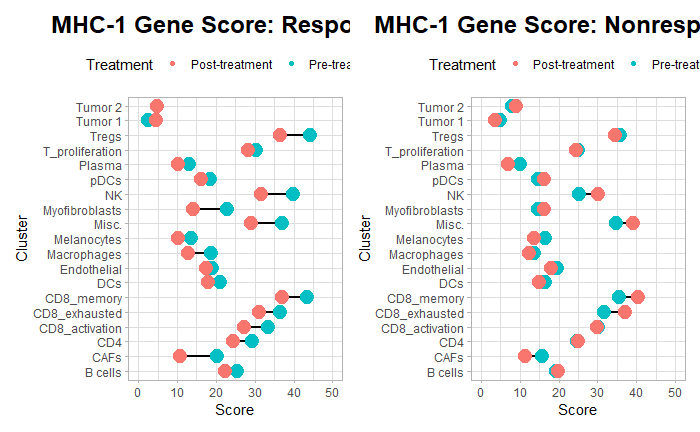

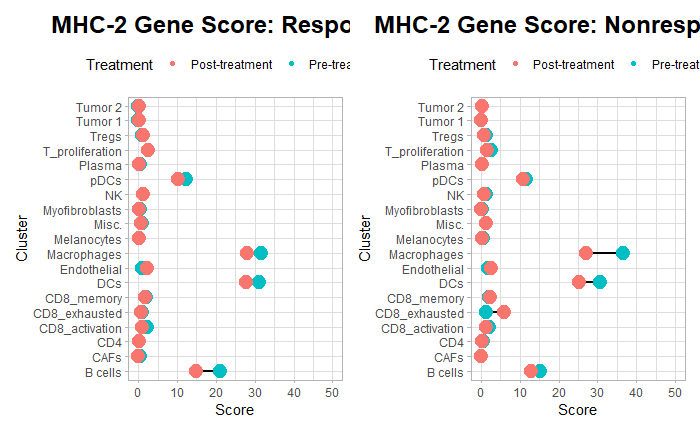

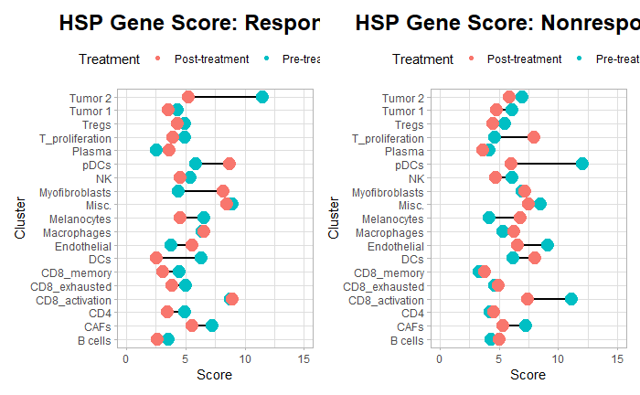

```r
BCC.responders.char <- c("BCC.su001", "BCC.su002", "BCC.su003", "BCC.su004", "BCC.su009", "BCC.su012")
BCC.nonresponders.char <- c("BCC.su005", "BCC.su006", "BCC.su007", "BCC.su008", "BCC.su010")

BCC.MHC1.scores$Responders <- rowMeans(BCC.MHC1.scores[,BCC.responders.char], na.rm=TRUE)
BCC.MHC1.scores$Nonresponders <- rowMeans(BCC.MHC1.scores[,BCC.nonresponders.char], na.rm=TRUE)

BCC.MHC1.scores.data <- data.frame(matrix(nrow=38))
BCC.MHC1.scores.data$xvals.responder <- BCC.MHC1.scores$Responders
BCC.MHC1.scores.data$xvals.nonresponder <- BCC.MHC1.scores$Nonresponders
BCC.MHC1.scores.data$Cluster <- rep(sort(levels(Idents(BCCIO))), each=2)
BCC.MHC1.scores.data$paired <- rep(1:length(levels(Idents(BCCIO))), each=2)
BCC.MHC1.scores.data$Treatment <- c("Pre-treatment", "Post-treatment")
BCC.MHC1.scores.data <- BCC.MHC1.scores.data[,-1]

BCC.MHC1.scores.dumbbell.responders <- BCC.MHC1.scores.data %>%
    ggplot(aes(x = xvals.responder, y = Cluster)) +
    labs(title = "MHC-1 Gene Score: Responders", x = "Score", y = "Cluster") +
    geom_line(aes(group = paired), color="black", size=1) +
    geom_point(aes(color = Treatment, size = 3)) +
    guides(size = FALSE) +
    theme_light() +
    theme(legend.position="top",
          plot.title = element_text(color="black", size=18, face="bold", hjust = 0.5)) +
    xlim(0,50)

BCC.MHC1.scores.dumbbell.nonresponders <- BCC.MHC1.scores.data %>%
    ggplot(aes(x = xvals.nonresponder, y = Cluster)) +
    labs(title = "MHC-1 Gene Score: Nonresponders", x = "Score", y = "Cluster") +
    geom_line(aes(group = paired), color="black", size=1) +
    geom_point(aes(color = Treatment, size = 3)) +
    guides(size = FALSE) +
    theme_light() +
    theme(legend.position="top",
          plot.title = element_text(color="black", size=18, face="bold", hjust = 0.5)) +
    xlim(0,50)

BCC.MHC1.scores.dumbbell.responders + BCC.MHC1.scores.dumbbell.nonresponders


BCC.MHC2.scores$Responders <- rowMeans(BCC.MHC2.scores[,BCC.responders.char], na.rm=TRUE)
BCC.MHC2.scores$Nonresponders <- rowMeans(BCC.MHC2.scores[,BCC.nonresponders.char], na.rm=TRUE)

BCC.MHC2.scores.data <- data.frame(matrix(nrow=38))
BCC.MHC2.scores.data$xvals.responder <- BCC.MHC2.scores$Responders
BCC.MHC2.scores.data$xvals.nonresponder <- BCC.MHC2.scores$Nonresponders
BCC.MHC2.scores.data$Cluster <- rep(sort(levels(Idents(BCCIO))), each=2)
BCC.MHC2.scores.data$paired <- rep(1:length(levels(Idents(BCCIO))), each=2)
BCC.MHC2.scores.data$Treatment <- c("Pre-treatment", "Post-treatment")
BCC.MHC2.scores.data <- BCC.MHC2.scores.data[,-1]

BCC.MHC2.scores.dumbbell.responders <- BCC.MHC2.scores.data %>%
    ggplot(aes(x = xvals.responder, y = Cluster)) +
    labs(title = "MHC-2 Gene Score: Responders", x = "Score", y = "Cluster") +
    geom_line(aes(group = paired), color="black", size=1) +
    geom_point(aes(color = Treatment, size = 3)) +
    guides(size = FALSE) +
    theme_light() +
    theme(legend.position="top",
          plot.title = element_text(color="black", size=18, face="bold", hjust = 0.5)) +
    xlim(0,50)

BCC.MHC2.scores.dumbbell.nonresponders <- BCC.MHC2.scores.data %>%
    ggplot(aes(x = xvals.nonresponder, y = Cluster)) +
    labs(title = "MHC-2 Gene Score: Nonresponders", x = "Score", y = "Cluster") +
    geom_line(aes(group = paired), color="black", size=1) +
    geom_point(aes(color = Treatment, size = 3)) +
    guides(size = FALSE) +
    theme_light() +
    theme(legend.position="top",
          plot.title = element_text(color="black", size=18, face="bold", hjust = 0.5)) +
    xlim(0,50)

BCC.MHC2.scores.dumbbell.responders + BCC.MHC2.scores.dumbbell.nonresponders



BCC.HSP.scores$Responders <- rowMeans(BCC.HSP.scores[,BCC.responders.char], na.rm=TRUE)
BCC.HSP.scores$Nonresponders <- rowMeans(BCC.HSP.scores[,BCC.nonresponders.char], na.rm=TRUE)

BCC.HSP.scores.data <- data.frame(matrix(nrow=38))
BCC.HSP.scores.data$xvals.responder <- BCC.HSP.scores$Responders
BCC.HSP.scores.data$xvals.nonresponder <- BCC.HSP.scores$Nonresponders
BCC.HSP.scores.data$Cluster <- rep(sort(levels(Idents(BCCIO))), each=2)
BCC.HSP.scores.data$paired <- rep(1:length(levels(Idents(BCCIO))), each=2)
BCC.HSP.scores.data$Treatment <- c("Pre-treatment", "Post-treatment")
BCC.HSP.scores.data <- BCC.HSP.scores.data[,-1]

BCC.HSP.scores.dumbbell.responders <- BCC.HSP.scores.data %>%
    ggplot(aes(x = xvals.responder, y = Cluster)) +
    labs(title = "HSP Gene Score: Responders", x = "Score", y = "Cluster") +
    geom_line(aes(group = paired), color="black", size=1) +
    geom_point(aes(color = Treatment, size = 3)) +
    guides(size = FALSE) +
    theme_light() +
    theme(legend.position="top",
          plot.title = element_text(color="black", size=18, face="bold", hjust = 0.5)) +
    xlim(0,15)

BCC.HSP.scores.dumbbell.nonresponders <- BCC.HSP.scores.data %>%
    ggplot(aes(x = xvals.nonresponder, y = Cluster)) +
    labs(title = "HSP Gene Score: Nonresponders", x = "Score", y = "Cluster") +
    geom_line(aes(group = paired), color="black", size=1) +
    geom_point(aes(color = Treatment, size = 3)) +
    guides(size = FALSE) +
    theme_light() +
    theme(legend.position="top",
          plot.title = element_text(color="black", size=18, face="bold", hjust = 0.5)) +
    xlim(0,15)

BCC.HSP.scores.dumbbell.responders + BCC.HSP.scores.dumbbell.nonresponders
```

Create dumbbell plots comparing only responders or nonresponders

```r
BCC_score_dumbbell(df=BCC.MHC1.scores.na, patient=1, xlim=50)
```

```
the condition has length > 1 and only the first element will be used
```